# Integrating AspWood, Spatial, and Single-cell data

Chia-Chen Chu

2025-10-23

# Overview

This notebook aims to integrate 3 datasets:  
1. AspWood data (now hosted by PlantGenIE.org)  
2. Visium data (from Quanzi’s paper) 3. 10x 3’ gene expression data (from Tung 2023)

# Setup library and variables

```r
library(magrittr)
library(data.table)
library(Seurat)
```

```r
library(ggplot2)
library(patchwork)
library(dplyr)
library(readxl)
library(spacexr)
library(MatrixGenerics)
library(pheatmap)
library(dendsort)

# AspWood
path_aspwood_tpm <- "rawdata/AspWood/AspWood_tpm.txt"
path_matches <- "rawdata/AspWood/run-diamond/matches.tsv"

# Spatial
path_spaceranger_out <- "/home/f06b22037/SSD2/JW/spaceranger_count_TenX_stemQuanzi2024_v3/outs/"

# Single-cell
path_cellranger_out <- "outputs/cellranger/reanalyze/ptr_tenx_batch1_rs17/outs/filtered_feature_bc_matrix/"
path_cell_ident = "outputs/Populus/barcode2color/ptr_tenx_batch1_rs17_curated.csv"

# Populus trichocarpa annotation files
path_annot_info = "references/Ptr/annotation/Ptrichocarpa_533_v4.1.annotation_info.txt"
```

# Preprocessing of the three datasets

## AspWood

Read data

```r
aspwood_tpm <- fread(path_aspwood_tpm)
# exclude phloem samples
# aspwood_tpm <- subset(aspwood_tpm, !grepl("Phloem", aspwood_tpm$sample_name))
dim(aspwood_tpm)
```

```
## [1] 3967025       3
```

```r
head(aspwood_tpm)
```

| gene_id | sample_name | expression |
| --- | --- | --- |
| Potra2c131s34673 | T1-Phloem-01 | 0 |
| Potra2c131s34673 | T1-Phloem-02 | 0 |
| Potra2c131s34673 | T1-Phloem-03 | 0 |
| Potra2c131s34673 | T1-Phloem-04 | 0 |
| Potra2c131s34673 | T1-Phloem-05 | 0 |
| Potra2c131s34673 | T1-Cambium-06 | 0 |

```r
aspwood_tpm_wide <- dcast(aspwood_tpm, gene_id ~ sample_name, value.var = "expression")
gene_ids <- aspwood_tpm_wide$gene_id
dim(aspwood_tpm_wide)
```

```
## [1] 37075   108
```

```r
aspwood_tpm_mtx <- as.matrix(aspwood_tpm_wide[,2:ncol(aspwood_tpm_wide)])
rownames(aspwood_tpm_mtx) <- gene_ids
dim(aspwood_tpm_mtx)
```

```
## [1] 37075   107
```

```r
aspwood_tpm_mtx[1:5, 1:5]
```

```
##                  T1-Cambium-06 T1-Cambium-07 T1-Cambium-08 T1-Cambium-09
## Potra2c131s34673      0.000000      0.000000      0.000000      0.000000
## Potra2c131s34674      0.000000      0.000000      0.000000      0.000000
## Potra2c131s34675      0.000000      0.000000      0.000000      0.000000
## Potra2c131s34676      0.406168      0.416407      0.177808      0.774915
## Potra2c131s34677      0.000000      0.839349      0.501632      2.204581
##                  T1-Cambium-10
## Potra2c131s34673      0.000000
## Potra2c131s34674      0.000000
## Potra2c131s34675      0.000000
## Potra2c131s34676      0.366347
## Potra2c131s34677      0.525401
```

### Convert *P. tremula* gene ID to *P. trichocarpa* gene ID using DAIMOND

- *P. tremula* protein fasta (v2.2) were downloaded from PlantGeneIE.org (ftp://plantgenie.org:980/Data/PlantGenIE/Populus_tremula/v2.2/fasta/Potra02_proteins.fasta.gz)
- *P. trichocarpa* protein fasta (v.4.1) were downloaded from Phytozome

Example of the code used to identify 1-to-1 best-hit between the two species:

```bash
# creating a diamond-formatted database file
docker run staphb/diamond:2.1.13 diamond makedb --in reference.fasta -d reference

# running a search in blastp mode
docker run staphb/diamond:2.1.13 diamond blastp -d reference -q queries.fasta -o matches.tsv
```

```r
ptr_matches <- fread(path_matches)
names(ptr_matches) <- c(
    "Query_accession",
    "Target_accession",
    "Sequence_identity",
    "Length",
    "Mismatches",
    "Gap_openings",
    "Query_start",
    "Query_end",
    "Target_start",
    "Target_end",
    "E_value",
    "Bit_score"
)
ptr_matches
```

| Query_accession | Target_accession | Sequence_identity | Length | Mismatches | Gap_openings | Query_start | Query_end | Target_start | Target_end | E_value | Bit_score |
| --- | --- | --- | --- | --- | --- | --- | --- | --- | --- | --- | --- |
| Potra2n765s36715.1 | Potri.003G203500.1.p | 92.1 | 316 | 21 | 1 | 1 | 312 | 1 | 316 | 2.430000e-201 | 553.0 |
| Potra2n765s36715.1 | Potri.003G203000.1.p | 35.0 | 323 | 181 | 12 | 1 | 312 | 1 | 305 | 1.190000e-37 | 135.0 |
| Potra2n765s36715.1 | Potri.001G021900.1.p | 32.8 | 296 | 171 | 8 | 20 | 308 | 26 | 300 | 7.020000e-36 | 131.0 |
| Potra2n765s36715.1 | Potri.001G022100.1.p | 32.1 | 321 | 184 | 9 | 1 | 308 | 1 | 300 | 8.170000e-36 | 131.0 |
| Potra2n765s36715.1 | Potri.001G021600.2.p | 31.5 | 305 | 185 | 10 | 18 | 311 | 16 | 307 | 2.180000e-32 | 122.0 |
| Potra2n765s36715.1 | Potri.001G022400.1.p | 33.0 | 261 | 155 | 8 | 20 | 272 | 25 | 273 | 8.860000e-30 | 115.0 |
| Potra2n765s36715.1 | Potri.001G021500.3.p | 31.8 | 302 | 180 | 10 | 18 | 306 | 42 | 330 | 1.010000e-24 | 102.0 |
| Potra2n765s36715.1 | Potri.019G023500.1.p | 28.5 | 312 | 174 | 11 | 12 | 302 | 18 | 301 | 9.230000e-22 | 93.2 |
| Potra2n765s36714.1 | Potri.003G203600.1.p | 98.3 | 517 | 9 | 0 | 189 | 705 | 1 | 517 | 0.000000e+00 | 1040.0 |
| Potra2n765s36714.1 | Potri.001G020900.1.p | 91.7 | 528 | 44 | 0 | 178 | 705 | 3 | 530 | 0.000000e+00 | 988.0 |

[output cut: 9990 more lines]

Filter match results

```r
# get best hit per transcript isoform
ptr_best_matches <- unique(ptr_matches, by = c("Query_accession"))
dim(ptr_best_matches)
```

```
## [1] 65207    12
```

```r
# get best hit per P. tremula gene
ptr_best_matches[, c("Query_accession") := tstrsplit(Query_accession, ".", fixed=TRUE, keep=1L)]
ptr_best_matches <- unique(ptr_best_matches, by = c("Query_accession"))
dim(ptr_best_matches)
```

```
## [1] 32296    12
```

```r
# get best hit per P. trichocarpa gene
annot_info <- fread(path_annot_info)
setkey(annot_info, peptideName)
annot_info[ptr_best_matches$Target_accession, "locusName"]
```

| locusName |
| --- |
| Potri.003G203500 |
| Potri.003G203600 |
| Potri.003G185850 |
| Potri.013G029700 |
| Potri.013G029700 |
| Potri.013G037700 |
| Potri.016G006400 |
| Potri.019G060900 |
| Potri.007G056400 |
| Potri.006G176600 |

[output cut: 9990 more lines]

```r
ptr_best_matches$Target_accession <- sapply(
    ptr_best_matches$Target_accession,
    function(x) {
        foo <- strsplit(x, "[.]") %>% unlist
        return(paste(foo[1], foo[2], sep = "."))
    }
)
ptr_rbest_matches <- unique(ptr_best_matches, by = c("Target_accession"))
dim(ptr_rbest_matches)
```

```
## [1] 26725    12
```

```r
# show result
ptr_rbest_matches
```

| Query_accession | Target_accession | Sequence_identity | Length | Mismatches | Gap_openings | Query_start | Query_end | Target_start | Target_end | E_value | Bit_score |
| --- | --- | --- | --- | --- | --- | --- | --- | --- | --- | --- | --- |
| Potra2n765s36715 | Potri.003G203500 | 92.1 | 316 | 21 | 1 | 1 | 312 | 1 | 316 | 2.430000e-201 | 553.0 |
| Potra2n765s36714 | Potri.003G203600 | 98.3 | 517 | 9 | 0 | 189 | 705 | 1 | 517 | 0.000000e+00 | 1040.0 |
| Potra2n1433s37070 | Potri.003G185850 | 74.5 | 357 | 49 | 5 | 1 | 318 | 1 | 354 | 1.380000e-174 | 505.0 |
| Potra2n581s36023 | Potri.013G029700 | 92.4 | 409 | 31 | 0 | 404 | 812 | 447 | 855 | 4.600000e-262 | 749.0 |
| Potra2n581s36024 | Potri.013G037700 | 94.1 | 592 | 32 | 2 | 1 | 589 | 1 | 592 | 0.000000e+00 | 1096.0 |
| Potra2n707s36547 | Potri.016G006400 | 95.7 | 93 | 4 | 0 | 7 | 99 | 183 | 275 | 5.060000e-60 | 185.0 |
| Potra2n409s35556 | Potri.019G060900 | 97.2 | 141 | 4 | 0 | 10 | 150 | 1059 | 1199 | 4.550000e-85 | 274.0 |
| Potra2n268s35171 | Potri.007G056400 | 94.9 | 295 | 15 | 0 | 1 | 295 | 956 | 1250 | 2.070000e-188 | 551.0 |
| Potra2n606s36124 | Potri.006G176600 | 77.1 | 48 | 10 | 1 | 10 | 56 | 258 | 305 | 4.810000e-16 | 70.5 |
| Potra2n606s36123 | Potri.013G133800 | 92.8 | 699 | 41 | 2 | 25 | 715 | 4 | 701 | 0.000000e+00 | 1207.0 |

[output cut: 9990 more lines]

Show the distribution of sequence similarity

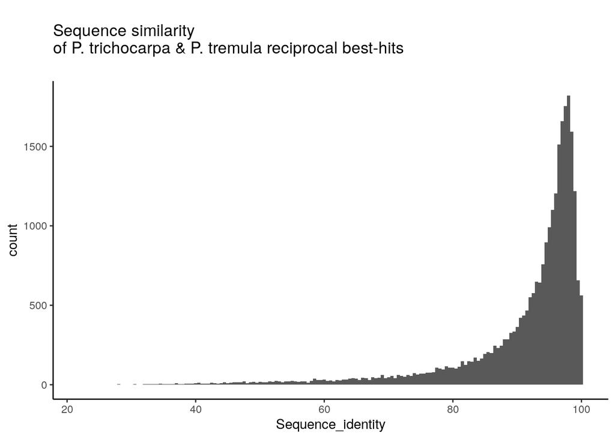

```r
ptr_rbest_matches %>%
    ggplot(aes(x = Sequence_identity)) +
    geom_histogram(binwidth=.5) +
    theme_classic() +
    labs(title = "
Sequence similarity
of P. trichocarpa & P. tremula reciprocal best-hits
    ")
```

```r
sum(ptr_rbest_matches$Sequence_identity > 80) / nrow(ptr_rbest_matches)
```

```
## [1] 0.8864733
```

```r
sum(ptr_rbest_matches$Sequence_identity > 70) / nrow(ptr_rbest_matches)
```

```
## [1] 0.9429373
```

```r
sum(ptr_rbest_matches$Sequence_identity > 60) / nrow(ptr_rbest_matches)
```

```
## [1] 0.9701403
```

```r
ptr_rbest_matches_60 <- subset(ptr_rbest_matches, ptr_rbest_matches$Sequence_identity > 60)
setkey(ptr_rbest_matches_60, Query_accession)
ptr_rbest_matches_60
```

| Query_accession | Target_accession | Sequence_identity | Length | Mismatches | Gap_openings | Query_start | Query_end | Target_start | Target_end | E_value | Bit_score |
| --- | --- | --- | --- | --- | --- | --- | --- | --- | --- | --- | --- |
| Potra2c499s35826 | Potri.011G075051 | 68.3 | 587 | 25 | 8 | 16 | 461 | 6 | 572 | 1.350000e-241 | 672.0 |
| Potra2n1015s36923 | Potri.012G038000 | 90.6 | 342 | 31 | 1 | 1 | 342 | 1 | 341 | 1.750000e-217 | 596.0 |
| Potra2n1025s36935 | Potri.006G281500 | 80.3 | 432 | 34 | 4 | 4 | 386 | 367 | 796 | 3.240000e-203 | 579.0 |
| Potra2n1041s36943 | Potri.001G409800 | 98.9 | 90 | 1 | 0 | 117 | 206 | 60 | 149 | 1.410000e-59 | 184.0 |
| Potra2n1048s36945 | Potri.001G423700 | 94.7 | 454 | 2 | 1 | 1 | 454 | 1 | 432 | 0.000000e+00 | 900.0 |
| Potra2n1048s36946 | Potri.001G423800 | 97.2 | 354 | 10 | 0 | 1 | 354 | 1 | 354 | 1.300000e-259 | 704.0 |
| Potra2n1055s36952 | Potri.019G073900 | 87.3 | 205 | 2 | 1 | 1 | 205 | 1 | 181 | 2.920000e-126 | 357.0 |
| Potra2n1059s36955 | Potri.017G137100 | 97.1 | 309 | 9 | 0 | 1 | 309 | 47 | 355 | 6.470000e-148 | 428.0 |
| Potra2n1069s36958 | Potri.005G014700 | 95.5 | 398 | 18 | 0 | 109 | 506 | 60 | 457 | 9.590000e-286 | 796.0 |
| Potra2n1069s36959 | Potri.013G009100 | 87.5 | 32 | 4 | 0 | 85 | 116 | 100 | 131 | 2.800000e-12 | 60.8 |

[output cut: 9990 more lines]

```r
mask <- rownames(aspwood_tpm_mtx) %in% ptr_rbest_matches_60$Query_accession
aspwood_tpm_mtx_rbest <- aspwood_tpm_mtx[mask, ]
dim(aspwood_tpm_mtx_rbest)
```

```
## [1] 25927   107
```

```r
aspwood_tpm_mtx_rbest[1:5, 1:5]
```

```
##                   T1-Cambium-06 T1-Cambium-07 T1-Cambium-08 T1-Cambium-09
## Potra2c499s35826       0.451939      0.000000      0.000000      0.000000
## Potra2n1015s36923      3.028108      3.552761      4.608483      3.612460
## Potra2n1025s36935      0.245219      0.139496      0.000000      0.066918
## Potra2n1041s36943     38.353196     41.295366     29.381231     24.894380
## Potra2n1048s36945     14.606742     16.324260     17.986477     20.064126
##                   T1-Cambium-10
## Potra2c499s35826       0.603327
## Potra2n1015s36923      0.103331
## Potra2n1025s36935      0.000000
## Potra2n1041s36943     15.810366
## Potra2n1048s36945     21.046574
```

```r
setkey(ptr_rbest_matches_60, Query_accession)
rownames(aspwood_tpm_mtx_rbest) <- ptr_rbest_matches_60[
    rownames(aspwood_tpm_mtx_rbest),
    "Target_accession"
] %>% unlist %>% unname
aspwood_tpm_mtx_rbest[1:5, 1:5]
```

```
##                  T1-Cambium-06 T1-Cambium-07 T1-Cambium-08 T1-Cambium-09
## Potri.011G075051      0.451939      0.000000      0.000000      0.000000
## Potri.012G038000      3.028108      3.552761      4.608483      3.612460
## Potri.006G281500      0.245219      0.139496      0.000000      0.066918
## Potri.001G409800     38.353196     41.295366     29.381231     24.894380
## Potri.001G423700     14.606742     16.324260     17.986477     20.064126
##                  T1-Cambium-10
## Potri.011G075051      0.603327
## Potri.012G038000      0.103331
## Potri.006G281500      0.000000
## Potri.001G409800     15.810366
## Potri.001G423700     21.046574
```

### Preprocessing

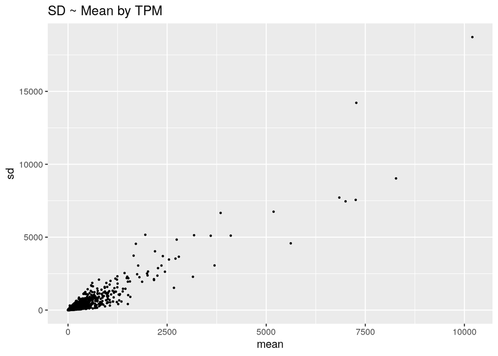

```r
data.frame(
    mean = MatrixGenerics::rowMeans2(aspwood_tpm_mtx_rbest),
    sd = MatrixGenerics::rowVars(aspwood_tpm_mtx_rbest) %>% sqrt
) %>% ggplot(aes(x = mean, y = sd)) +
    geom_point(size = .5) +
    labs(title = "SD ~ Mean by TPM")
```

### Plot SD ~ Mean

Variance stabilization (using TPM as input for log2 transformation)

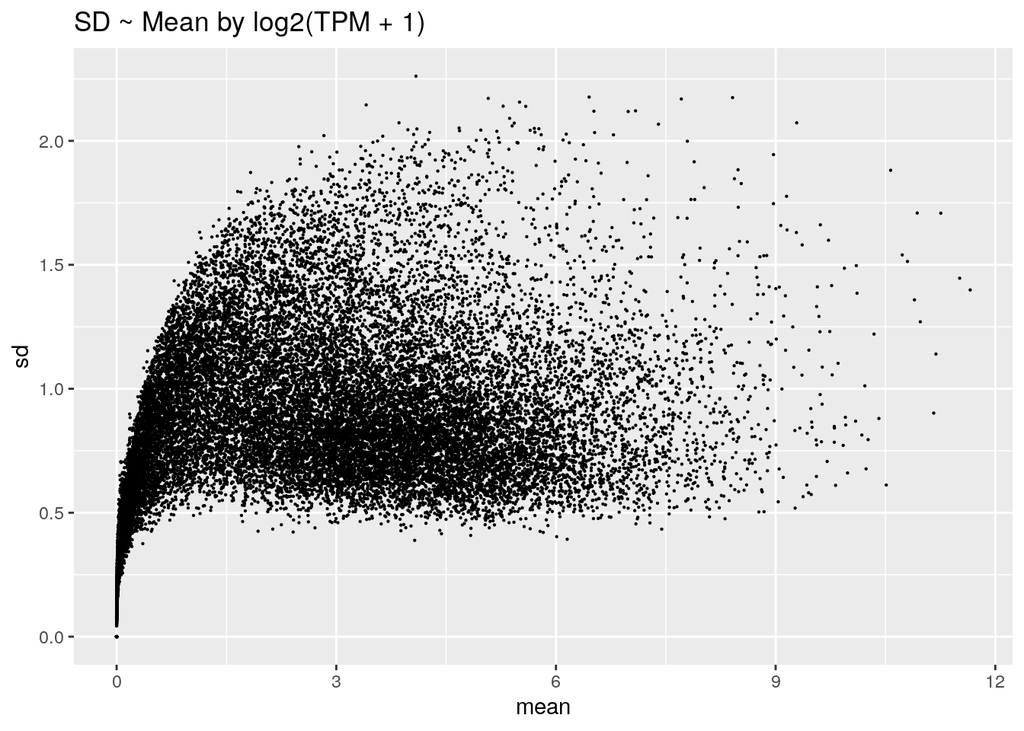

```r
aspwood_log2_tpm_mtx_rbest <- log2(aspwood_tpm_mtx_rbest + 1)
data.frame(
    mean = MatrixGenerics::rowMeans2(aspwood_log2_tpm_mtx_rbest),
    sd = MatrixGenerics::rowSds(aspwood_log2_tpm_mtx_rbest) %>% sqrt
) %>% ggplot(aes(x = mean, y = sd)) +
    geom_point(size = .1) +
    labs(title = "SD ~ Mean by log2(TPM + 1)")
```

## Spatial data

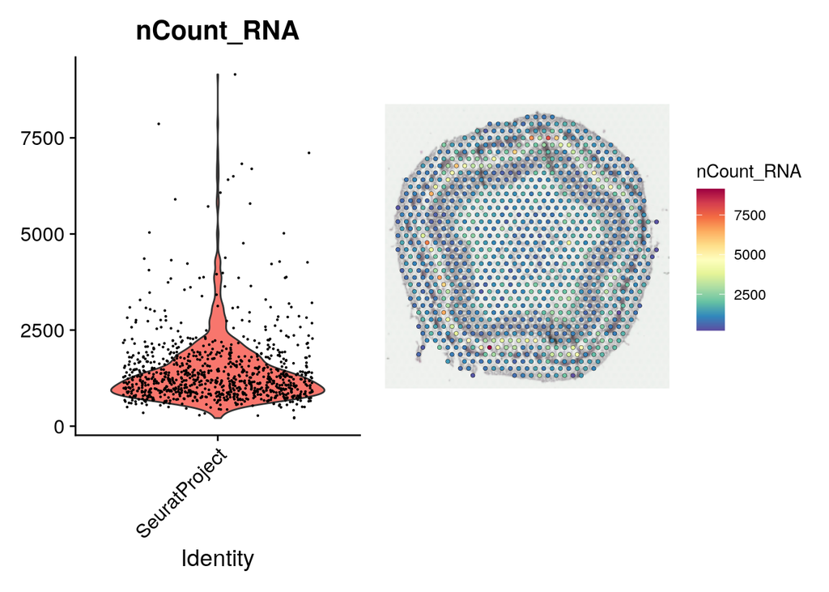

```r
sp_data <- Load10X_Spatial(
    data.dir=path_spaceranger_out,
    filename = "filtered_feature_bc_matrix.h5",
    assay = "RNA"
)
p1 <- VlnPlot(sp_data, features = "nCount_RNA", pt.size = 0.1) + NoLegend()
p2 <- SpatialFeaturePlot(sp_data, features = "nCount_RNA") + theme(legend.position = "right")
p1 | p2
```

### Preprocessing

```r
sp_data <- SCTransform(sp_data, return.only.var.genes = FALSE)
```

```
## Running SCTransform on assay: RNA
```

```
## Running SCTransform on layer: counts
```

```
## vst.flavor='v2' set. Using model with fixed slope and excluding poisson genes.
```

```
## Variance stabilizing transformation of count matrix of size 18704 by 947
```

```
## Model formula is y ~ log_umi
```

```
## Get Negative Binomial regression parameters per gene
```

```
## Using 2000 genes, 947 cells
```

[output not shown]

[output cut: 16 more lines]

[output not shown]

```
## Found 2 outliers - those will be ignored in fitting/regularization step
```

```
## Second step: Get residuals using fitted parameters for 18704 genes
```

```
## Computing corrected count matrix for 18704 genes
```

```
## Wall clock passed: Time difference of 10.9045 secs
```

```
## Determine variable features
```

```
## Centering data matrix
```

```
## Set default assay to SCT
```

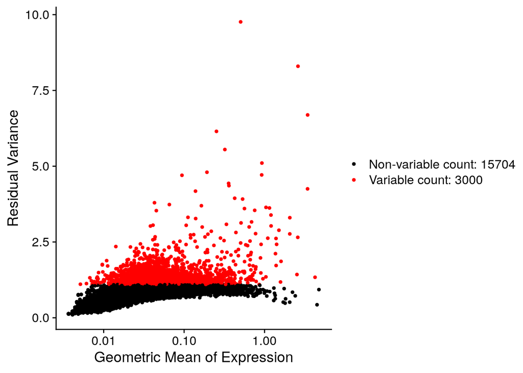

```r
VariableFeaturePlot(sp_data)
```

### SNN based clustering

First round cluster

```r
sp_data <- RunPCA(sp_data)
```

[output not shown]

[output cut: 12 more lines]

```r
sp_data <- FindNeighbors(sp_data, reduction = "pca", dims = 1:30)
sp_data <- FindClusters(sp_data, resolution = 0.8)
```

```
## Modularity Optimizer version 1.3.0 by Ludo Waltman and Nees Jan van Eck
##
## Number of nodes: 947
## Number of edges: 43996
##
## Running Louvain algorithm...
## Maximum modularity in 10 random starts: 0.7551
## Number of communities: 8
## Elapsed time: 0 seconds
```

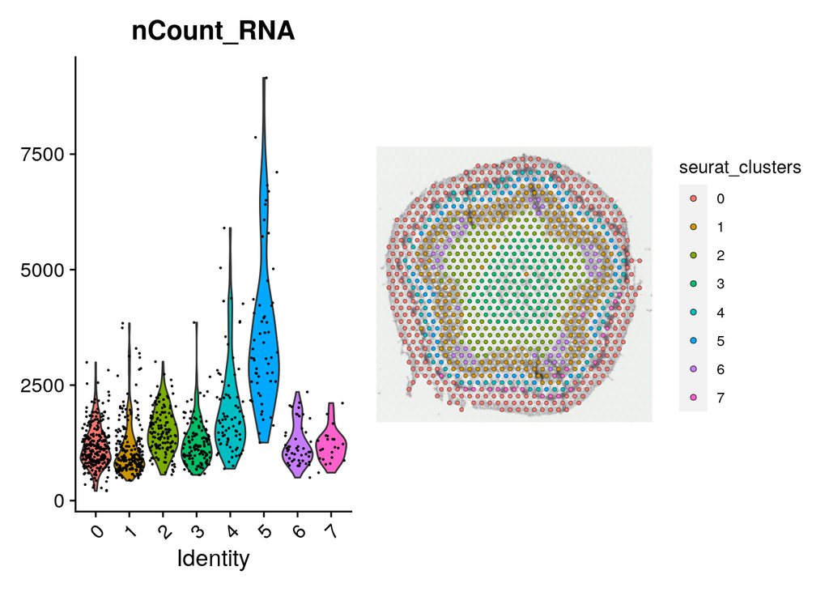

```r
p1 <- VlnPlot(sp_data, features = "nCount_RNA", pt.size = 0.1) + NoLegend()
p2 <- SpatialDimPlot(sp_data, group.by = "seurat_clusters") + theme(legend.position = "right")
p1 | p2
```

Exclude cluster spatial outliers

```r
spatial_outliers <- c(
  "CCGGCGCATATTGGAT-1",
  "GAGCGAGGGAGTACCG-1",
  "ATCGACTCTTTCCGTT-1",
  "GCTCTCGGGTACCGAA-1",
  "TCCCGCGTACTCCTGG-1",
  "ATTGCTGCTCCTCCAT-1",
  "TTGTAATCCGTACTCG-1",
  "ATGCCGGTTGATGGGA-1"
)
sp_data_outlier_rm <- subset(sp_data, cells = spatial_outliers, invert = TRUE)
sp_data_outlier_rm <- subset(sp_data_outlier_rm, idents = c(1, 4, 5, 6))
```

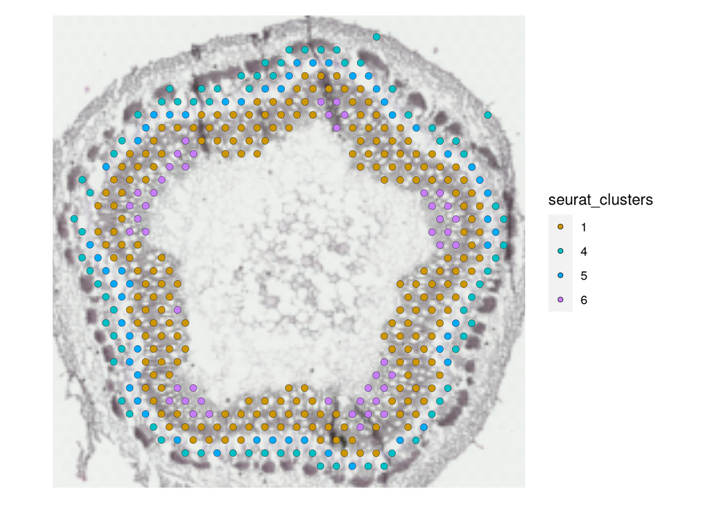

```r
SpatialDimPlot(sp_data_outlier_rm, group.by = "seurat_clusters")
```

Get xylem sub-cluster

```r
sp_data_outlier_rm <- FindSubCluster(sp_data_outlier_rm, cluster = 1, graph.name = "SCT_nn")
```

```
## Modularity Optimizer version 1.3.0 by Ludo Waltman and Nees Jan van Eck
##
## Number of nodes: 213
## Number of edges: 1609
##
## Running Louvain algorithm...
## Maximum modularity in 10 random starts: 0.6302
## Number of communities: 4
## Elapsed time: 0 seconds
```

```
## 1 singletons identified. 3 final clusters.
```

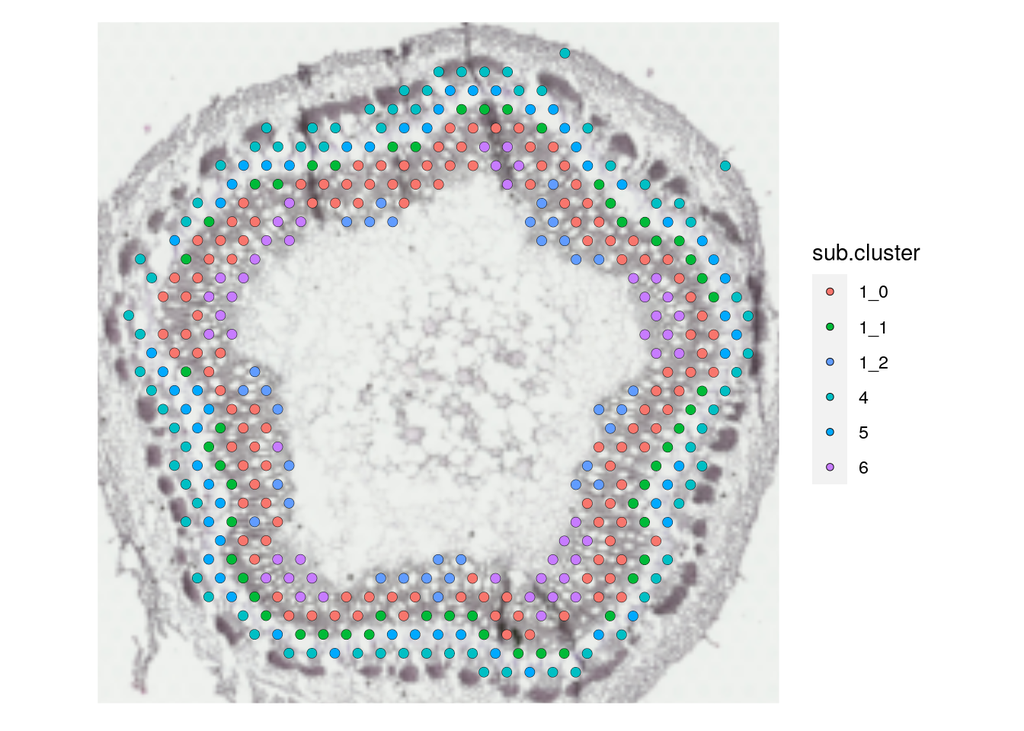

```r
colors <- c(
    "0" = "#F8766D",
    "1_0" = "#F8766D",
    "1_1" = "#00BA38",
    "1_2" = "#619CFF",
    "2" = "#7CAE00",
    "3" = "#00BE67",
    "4" = "#00BFC4",
    "5" = "#00A9FF",
    "6" = "#C77CFF",
    "7" = "#FF61CC"
)
SpatialDimPlot(sp_data_outlier_rm, group.by = "sub.cluster") +
    scale_fill_manual(values = colors)
```

Name clusters

```r
sp_celltype <- sp_data_outlier_rm$sub.cluster
sp_celltype[sp_celltype == "0"] <- "sp-bark"
sp_celltype[sp_celltype == "1_0"] <- "sp-midXylem"
sp_celltype[sp_celltype == "1_1"] <- "sp-earlyXylem"
sp_celltype[sp_celltype == "1_2"] <- "sp-lateXylem"
sp_celltype[sp_celltype == "2"] <- "sp-outerPith"
sp_celltype[sp_celltype == "3"] <- "sp-innerPith"
sp_celltype[sp_celltype == "4"] <- "sp-cambiumPhloem"
sp_celltype[sp_celltype == "5"] <- "sp-cambiumXylem"
sp_celltype[sp_celltype == "6"] <- "sp-primaryXylem"
sp_celltype[sp_celltype == "7"] <- "sp-phloemDark"
sp_data_outlier_rm$celltype <- sp_celltype
```

Aggregate expression by sub.cluster

```r
Idents(sp_data_outlier_rm) <- "celltype"
aggregated_count <- AggregateExpression(sp_data_outlier_rm)$SCT
aggregated_count <- as.matrix(aggregated_count)
dim(aggregated_count)
```

```
## [1] 18704     6
```

```r
aggregated_count[1:5, 1:5]
```

```
##                       sp-midXylem sp-cambiumXylem sp-primaryXylem
## Potri.001G000400.v4.1           7               6               7
## Potri.001G000700.v4.1           6               3               0
## Potri.001G000800.v4.1           1               0               1
## Potri.001G000900.v4.1          39              13              16
## Potri.001G001300.v4.1           3               5               1
##                       sp-cambiumPhloem sp-earlyXylem
## Potri.001G000400.v4.1                5             3
## Potri.001G000700.v4.1               10             1
## Potri.001G000800.v4.1                1             3
## Potri.001G000900.v4.1               22            18
## Potri.001G001300.v4.1                7             3
```

### Plot SD ~ Mean

```r
p1 <- data.frame(
    mean = MatrixGenerics::rowMeans2(aggregated_count),
    sd = MatrixGenerics::rowSds(aggregated_count)
) %>% ggplot(aes(x = mean, y = sd)) +
    geom_point(size = .1) +
    labs(title = "SD ~ Mean - Pseudo-bulk counts")
sp_log2 <- log2(aggregated_count + 1)
p4 <- data.frame(
    mean = MatrixGenerics::rowMeans2(sp_log2),
    sd = MatrixGenerics::rowSds(sp_log2)
) %>% ggplot(aes(x = mean, y = sd)) +
    geom_point(size = .1) +
    labs(title = "SD ~ Mean - Pseudo-bulk counts > log2")
sp_vst <- DESeq2::vst(aggregated_count)
```

```
## -- note: fitType='parametric', but the dispersion trend was not well captured by the
##    function: y = a/x + b, and a local regression fit was automatically substituted.
##    specify fitType='local' or 'mean' to avoid this message next time.
```

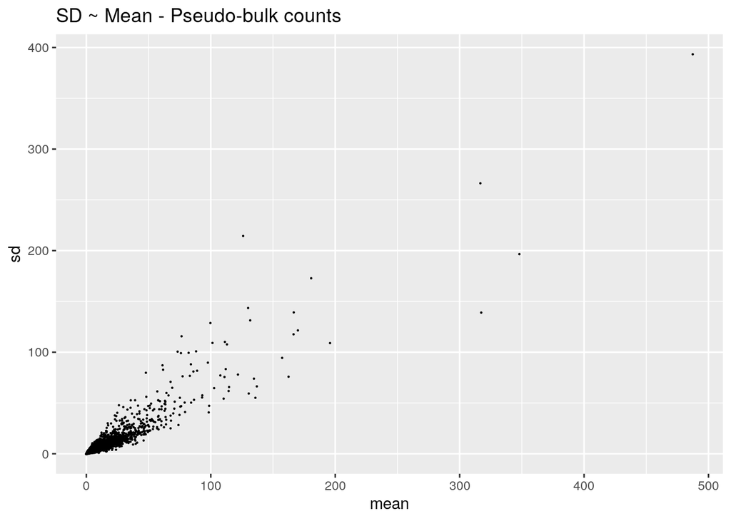

```r
p2 <- data.frame(
    mean = MatrixGenerics::rowMeans2(sp_vst),
    sd = MatrixGenerics::rowSds(sp_vst)
) %>% ggplot(aes(x = mean, y = sd)) +
    geom_point(size = .1) +
    labs(title = "SD ~ Mean - Pseudo-bulk counts > vst")
sp_rlog <- DESeq2::rlog(aggregated_count)
p3 <- data.frame(
    mean = MatrixGenerics::rowMeans2(sp_rlog),
    sd = MatrixGenerics::rowSds(sp_rlog)
) %>% ggplot(aes(x = mean, y = sd)) +
    geom_point(size = .1) +
    labs(title = "SD ~ Mean - Pseudo-bulk counts > rlog")
p1
```

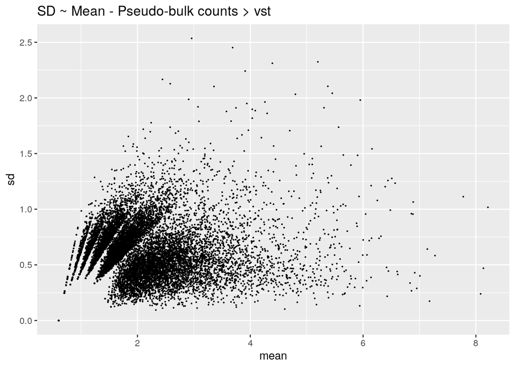

```r
p2
```

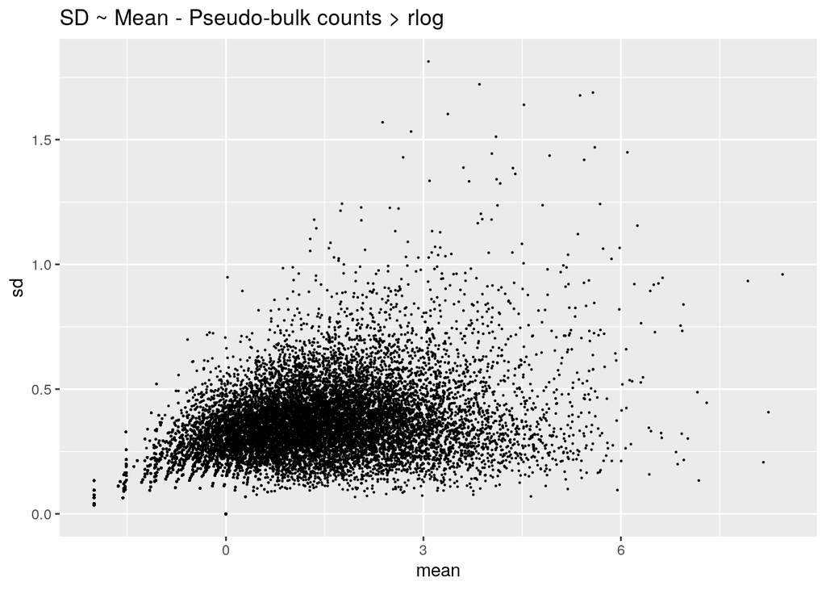

```r
p3
```

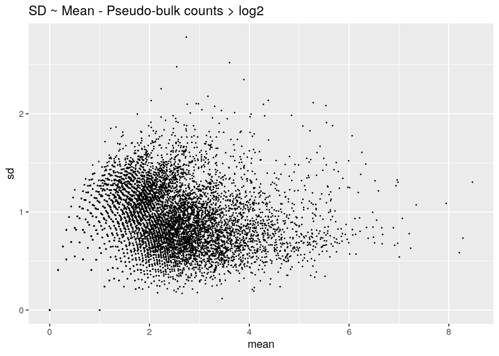

```r
p4
```

## Single-cell data

Read data

```r
sc_data <- Read10X(data.dir=path_cellranger_out)
cell_ident <- read.csv(path_cell_ident, header = TRUE, row.names = 1)
cluster <- cell_ident$Cluster
cluster[cluster == 1] <- "sc-Vessel"
cluster[cluster == 2] <- "sc-FuIP"
cluster[cluster == 3] <- "sc-RO"
cluster[cluster == 4] <- "sc-RP"
cluster[cluster == 5] <- "sc-FuEP"
cluster[cluster == 6] <- "sc-FuO"
cluster[cluster == 7] <- "sc-Fiber"
cluster[cluster == 8] <- "sc-Ray"
cluster[cluster == 9] <- "sc-outlier1"
cluster[cluster == 10] <- "sc-outlier2"
cluster[cluster == 11] <- "sc-outlier3"
names(cluster) <- rownames(cell_ident)
sc_data <- CreateSeuratObject(counts = sc_data, project = "ptr_tenx_batch1_rs17")
sc_data$cluster <- cluster
Idents(sc_data) <- "cluster"
```

Exclude outlier cells

```r
sc_data <- subset(
    sc_data,
    idents = c("sc-outlier1", "sc-outlier2", "sc-outlier3"),
    invert = TRUE
)
```

Aggregate data

```r
sc_data <- SCTransform(sc_data)
```

```
## Running SCTransform on assay: RNA
```

```
## Running SCTransform on layer: counts
```

```
## vst.flavor='v2' set. Using model with fixed slope and excluding poisson genes.
```

```
## Variance stabilizing transformation of count matrix of size 25038 by 4561
```

```
## Model formula is y ~ log_umi
```

```
## Get Negative Binomial regression parameters per gene
```

```
## Using 2000 genes, 4561 cells
```

[output not shown]

[output cut: 16 more lines]

[output not shown]

```
## Found 15 outliers - those will be ignored in fitting/regularization step
```

```
## Second step: Get residuals using fitted parameters for 25038 genes
```

```
## Computing corrected count matrix for 25038 genes
```

```
## Wall clock passed: Time difference of 40.05884 secs
```

```
## Determine variable features
```

```
## Centering data matrix
```

```
## Set default assay to SCT
```

```r
aggregated_count <- AggregateExpression(sc_data)$SCT
aggregated_count <- as.matrix(aggregated_count)
dim(aggregated_count)
```

```
## [1] 25038     8
```

```r
aggregated_count[1:5, 1:5]
```

```
##                       sc-Ray sc-Fiber sc-RO sc-Vessel sc-FuO
## Potri.001G000400.v4.1     14      116   324       335    205
## Potri.001G000450.v4.1      0        0     0         0      0
## Potri.001G000700.v4.1      4       57    29        62      9
## Potri.001G000900.v4.1     31      113   110       276     54
## Potri.001G001100.v4.1      0        0     0         0      0
```

### Plot SD ~ Mean

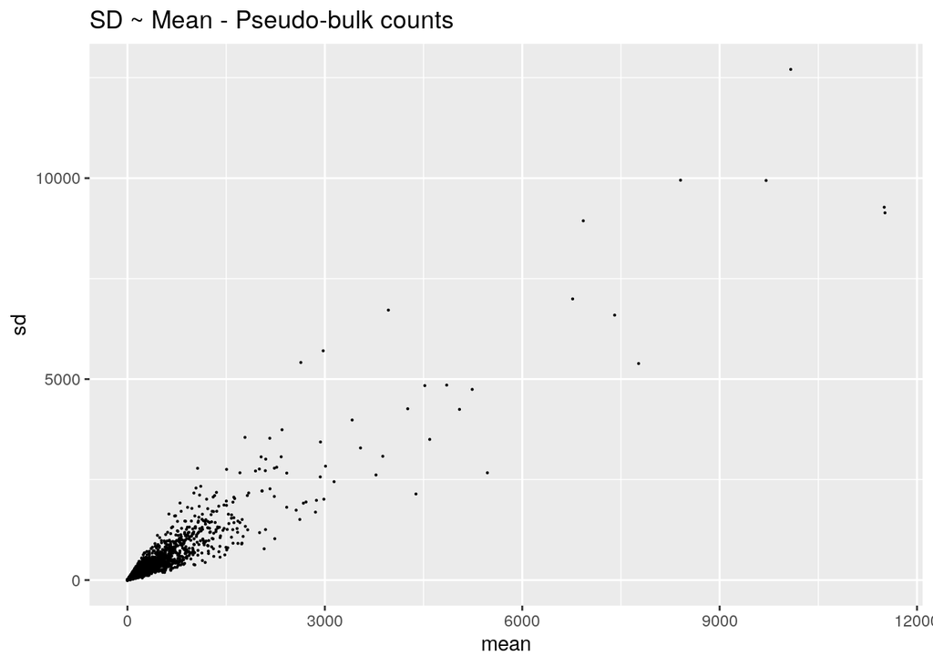

```r
p1 <- data.frame(
    mean = MatrixGenerics::rowMeans2(aggregated_count),
    sd = MatrixGenerics::rowSds(aggregated_count)
) %>% ggplot(aes(x = mean, y = sd)) +
    geom_point(size = .1) +
    labs(title = "SD ~ Mean - Pseudo-bulk counts")
sc_log2 <- log2(aggregated_count + 1)
p4 <- data.frame(
    mean = MatrixGenerics::rowMeans2(sc_log2),
    sd = MatrixGenerics::rowSds(sc_log2)
) %>% ggplot(aes(x = mean, y = sd)) +
    geom_point(size = .1) +
    labs(title = "SD ~ Mean - Pseudo-bulk log2 counts")
sc_vst <- DESeq2::vst(aggregated_count)
p2 <- data.frame(
    mean = MatrixGenerics::rowMeans2(sc_vst),
    sd = MatrixGenerics::rowSds(sc_vst)
) %>% ggplot(aes(x = mean, y = sd)) +
    geom_point(size = .1) +
    labs(title = "SD ~ Mean - Pseudo-bulk counts > vst")
sc_rlog <- DESeq2::rlog(aggregated_count)
p3 <- data.frame(
    mean = MatrixGenerics::rowMeans2(sc_rlog),
    sd = MatrixGenerics::rowSds(sc_rlog)
) %>% ggplot(aes(x = mean, y = sd)) +
    geom_point(size = .01) +
    labs(title = "SD ~ Mean - Pseudo-bulk counts > rlog")
p1
```

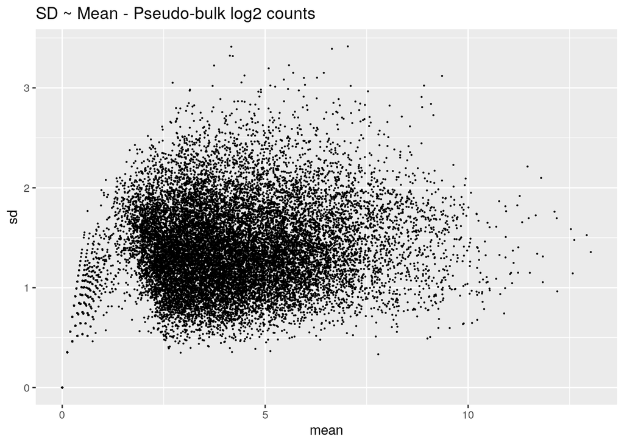

```r
p4
```

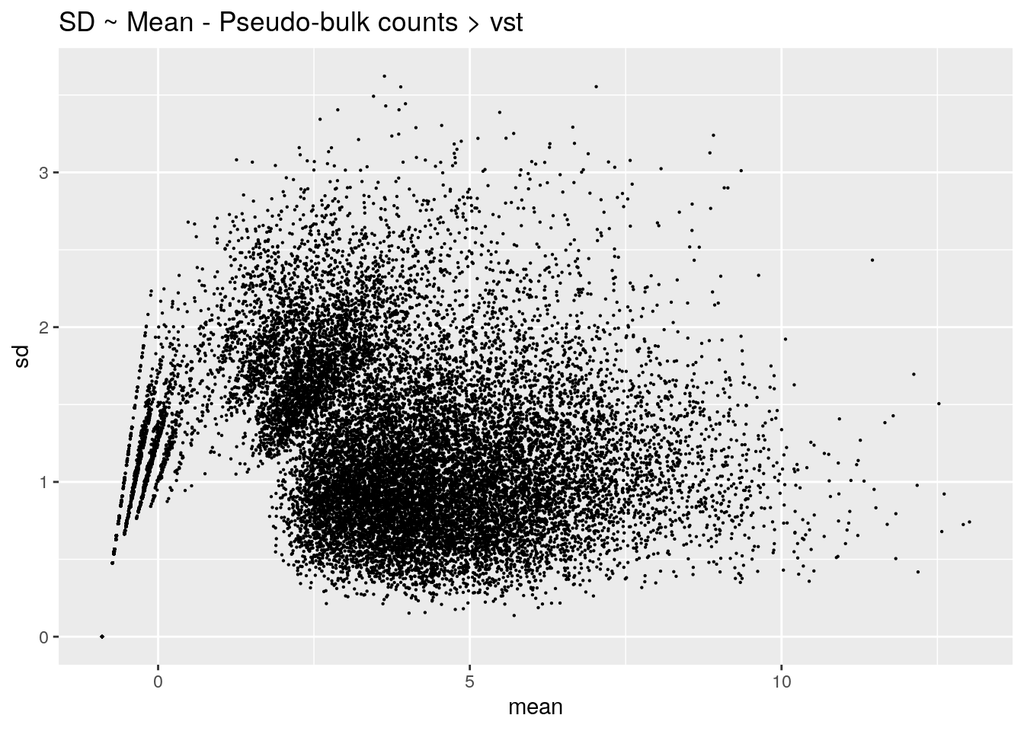

```r
p2
```

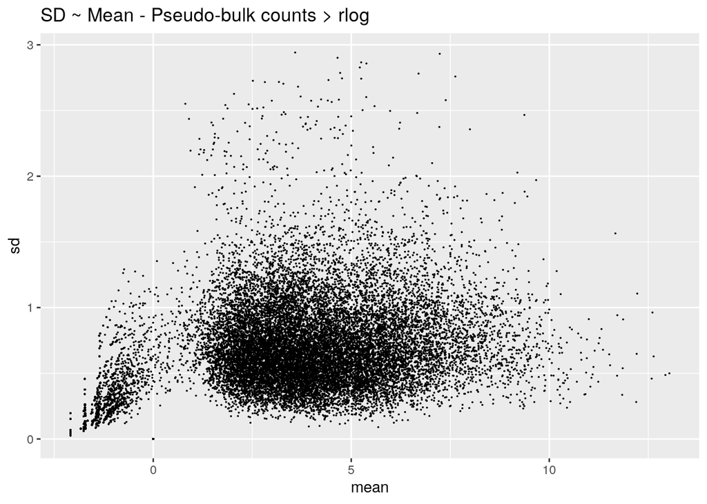

```r
p3
```

## Try integrating

Some peptides provided by Phytozome were not from the annotated loci

```r
# use vst normalized expression for single-cell and spatial data
sc_normalized_expression <- sc_log2
sp_normalized_expression <- sp_log2
aspwood_normalized_expression <- aspwood_log2_tpm_mtx_rbest

# re-format gene IDs (format: Potri.01G000000)
rownames(sc_normalized_expression) %<>% sapply(function(x){
    foo <- strsplit(x, "[.]")[[1]]
    return(paste(foo[1], foo[2], sep = "."))
}) %>% unname
rownames(sp_normalized_expression)  %<>% sapply(function(x){
    foo <- strsplit(x, "[.]")[[1]]
    return(paste(foo[1], foo[2], sep = "."))
}) %>% unname

#
cat(
    "No. peptides not included in GTF:",
    sum(!rownames(aspwood_log2_tpm_mtx_rbest) %in% rownames(sp_normalized_expression))
)
```

```
## No. peptides not included in GTF: 9352
```

```r
common_gids <- intersect(
    rownames(sc_normalized_expression),
    rownames(aspwood_normalized_expression)
)
common_gids <- intersect(
    common_gids,
    rownames(sp_normalized_expression)
)
cat(
    "No. common gene ID:",
    nrow(aspwood_normalized_expression)
)
```

[output not shown]

```r
sc_normalized_expression <- sc_normalized_expression[common_gids, ]
sp_normalized_expression <- sp_normalized_expression[common_gids, ]
aspwood_normalized_expression <- aspwood_normalized_expression[common_gids, ]
```

```r
df <- data.frame()
df %<>% rbind(data.frame(
    "source" = "single-cell",
    "sd" = MatrixGenerics::rowSds(sc_normalized_expression),
    "mean" = MatrixGenerics::rowMeans2(sc_normalized_expression)
))
df %<>% rbind(data.frame(
    "source" = "spatial",
    "sd" = MatrixGenerics::rowSds(sp_normalized_expression),
    "mean" = MatrixGenerics::rowMeans2(sp_normalized_expression)
))
df %<>% rbind(data.frame(
    "source" = "aspwood",
    "sd" = MatrixGenerics::rowSds(aspwood_normalized_expression),
    "mean" = MatrixGenerics::rowMeans2(aspwood_normalized_expression)
))
```

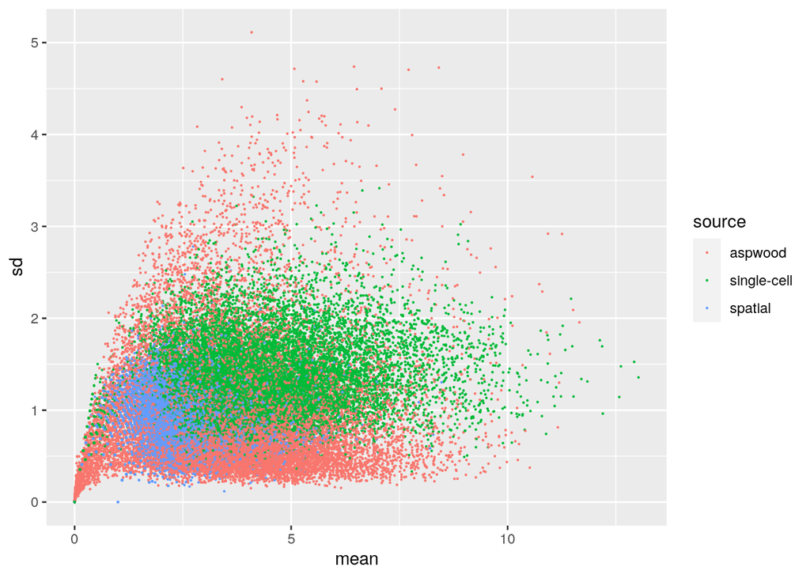

```r
ggplot(df %>% sample_frac(.), aes(x = mean, y = sd, color = source)) +
    geom_point(size = .1)
```

### (Deprecated) Z-score normalize data

This step produce NA, which should be filtered after combining data

```r
# ZscoreNormalize <-  function(x) {
#     apply(x, MARGIN = 1, function(x) {(x - median(x)) / sd(x)}) %>% t
# }
# sc_normalized_expression %<>% ZscoreNormalize
# sp_normalized_expression %<>% ZscoreNormalize
# aspwood_normalized_expression %<>% ZscoreNormalize
```

### Center rows per datasets

```r
centerData <- function(x) {
    foo <- apply(x, MARGIN = 1, function(x){
        x - mean(x)
    }) %>% t
    return(foo)
}
sc_normalized_expression %<>% centerData
sp_normalized_expression %<>% centerData
aspwood_normalized_expression %<>% centerData
```

### (Deprecated) Scale data

```r
# scaleData <- function(x) {
#     foo <- apply(x, MARGIN = 1, function(x){
#         variance <- var(x)
#         if (variance == 0) {
#             return(x)
#         } else {
#             return(x / sd(x))
#         }
#     }) %>% t
#     return(foo)
# }
# sc_normalized_expression %<>% scaleData
# sp_normalized_expression %<>% scaleData
# aspwood_normalized_expression %<>% scaleData
```

### Combine data

```r
combined_normalized_expression <- cbind(
    sc_normalized_expression,
    sp_normalized_expression
)
combined_normalized_expression <- cbind(
    combined_normalized_expression,
    aspwood_normalized_expression
)
dim(combined_normalized_expression)
```

```
## [1] 15835   121
```

Remove row containing NA

```r
combined_normalized_expression <- subset(
    combined_normalized_expression,
    !MatrixGenerics::rowAnyNAs(combined_normalized_expression)
)
dim(combined_normalized_expression)
```

```
## [1] 15835   121
```

### Scale columns (sample)

```r
# combined_normalized_expression <- combined_normalized_expression %>% apply(
#     MARGIN = 2,
#     function(x) {
#         (x - mean(x)) / sd(x)
#     }
# )
```

### PCA

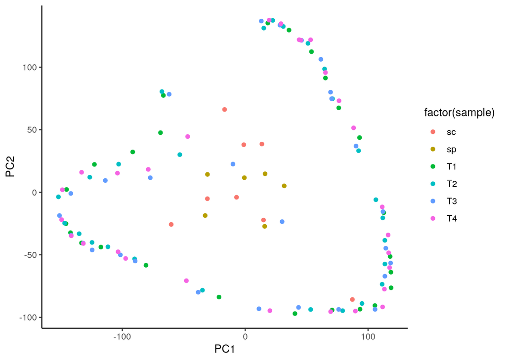

```r
pca_result <- irlba::prcomp_irlba(
    t(combined_normalized_expression),
    n = 2,
    center = FALSE,
    scale. = FALSE
)
pca_projection <- pca_result$x
plot_data <- data.frame(pca_projection[, c("PC1", "PC2")])
plot_data$sample <- colnames(combined_normalized_expression) %>% substring(1, 2)
ggplot(plot_data, aes(x = PC1, y = PC2, color = factor(sample))) +
    geom_point() +
    theme_classic()
```

### Heatmap + clustering

```r
# select top N variable genes
row_sd <- MatrixGenerics::rowSds(combined_normalized_expression)
```

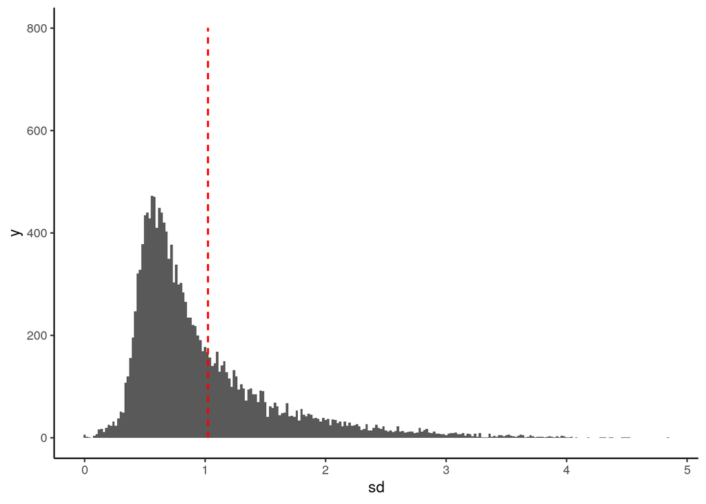

```r
ggplot(data.frame(sd = row_sd), aes(x = sd)) +
    geom_histogram(binwidth = .02) +
    geom_segment(
        aes(x = sort(row_sd, decreasing = TRUE)[5000], y = .1,
            xend = sort(row_sd, decreasing = TRUE)[5000], yend = 800),
        linetype="dashed",
        color = "red"
    ) +
    theme_classic()
```

Use top N variable genes

```r
top_var_genes <- rownames(combined_normalized_expression)[row_sd > 0]; length(top_var_genes)
```

```
## [1] 15831
```

```r
# top_var_genes <- rownames(combined_normalized_expression)[order(row_sd, decreasing = TRUE)][1:5000]
```

### Clustering samples based on correlation

```r
# set column annotations
annotation_col <- data.frame(
    Source = c(
        rep("SC", ncol(sc_normalized_expression)),
        rep("SP", ncol(sp_normalized_expression)),
        rep("Asp", ncol(aspwood_normalized_expression))
    )
)
rownames(annotation_col) <- colnames(combined_normalized_expression)

# set color for column annoation
annotation_colors <- list(
  Source = c(SC = "#F8766D", SP = "#00BA38", Asp = "#619CFF")
)

#
callback_dendsort <- function(hc, ...){
  dendsort(hc, isReverse = TRUE)
}

# create heatmap
ph <- pheatmap(
    combined_normalized_expression[top_var_genes, ],
    kmeans_k = 30,
    color = colorRampPalette(c("navy", "white", "firebrick3"))(100),
    annotation_col = annotation_col,
    annotation_colors = annotation_colors,
    clustering_distance_rows = "correlation",
    clustering_distance_cols = "correlation",
    clustering_method = "complete",
    cutree_rows = 10,
    cutree_cols = 11,
    clustering_callback = callback_dendsort,
    scale = "column",
    fontsize_col = 14,
    fontsize_row = 14,
    border_color = "gray60",
    filename = "outputs/notebook/Integrating_3_technologies/heatmap_SCT_log2.pdf",
    width = 28,
    height = 14
)
```

Get member of gene clusters

```r
setkey(annot_info, locusName)
cluster_genes <- which(ph$kmeans$cluster == 33) %>% names
cluster_genes_ath_best <- annot_info[cluster_genes, "best_arabi_gene"] %>% unlist %>% unname
unmatched_cluster_genes <- cluster_genes[cluster_genes_ath_best == ""] %>% na.omit
cluster_genes_ath_best <- cluster_genes_ath_best[cluster_genes_ath_best != ""]
cat(cluster_genes_ath_best, "\n")
```

```r
cat(unmatched_cluster_genes)
```